# Image Data Summary

2024-06-06

# June 2024 Summary of Hollister Ranch Coastal Wildlife Camera Trapping Study

## Draft Map of all Hollister Ranch Cameras

### (final draft will include Dangermond cameras)

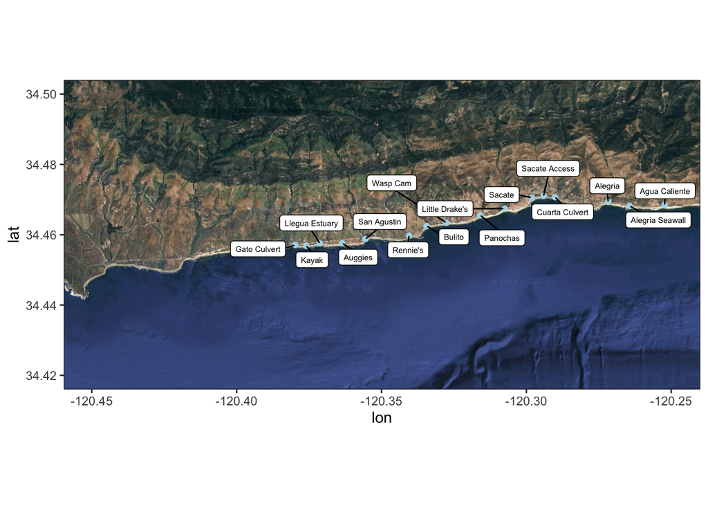

## Summarizing the data for some quick visualizations

| Camera Location (N to S) | Total Images Taken | Number of Animal Sightings | Number of Human Sightings | Number of Unique Species | Percent of Images Containing Animals |
| --- | --- | --- | --- | --- | --- |
| Gato | 7803 | 1622 | 1300 | 21 | 20.786877 |
| Kayak (St. Augustine West) | 29149 | 808 | 453 | 12 | 2.771965 |
| Llegua | 8943 | 866 | 891 | 14 | 9.683551 |
| Auggie’s | 39824 | 1040 | 117 | 17 | 2.611491 |
| Rennie’s | 114 | 7 | 4 | 3 | 6.140351 |
| Bulito | 8283 | 238 | 246 | 10 | 2.873355 |
| Panochas | 10679 | 657 | 174 | 13 | 6.152261 |
| Little Drake’s | 11793 | 664 | 537 | 12 | 5.630459 |
| Sacate | 2506 | 966 | 472 | 13 | 38.547486 |
| Cuarta | 9 | 2 | NA | 1 | 22.222222 |
| Alegria | 8022 | 1965 | 545 | 34 | 24.495138 |
| Caliente | 3309 | 169 | 651 | 14 | 5.107283 |

## Some plots to summarize preliminary data

### Total nights that cameras were active at each location

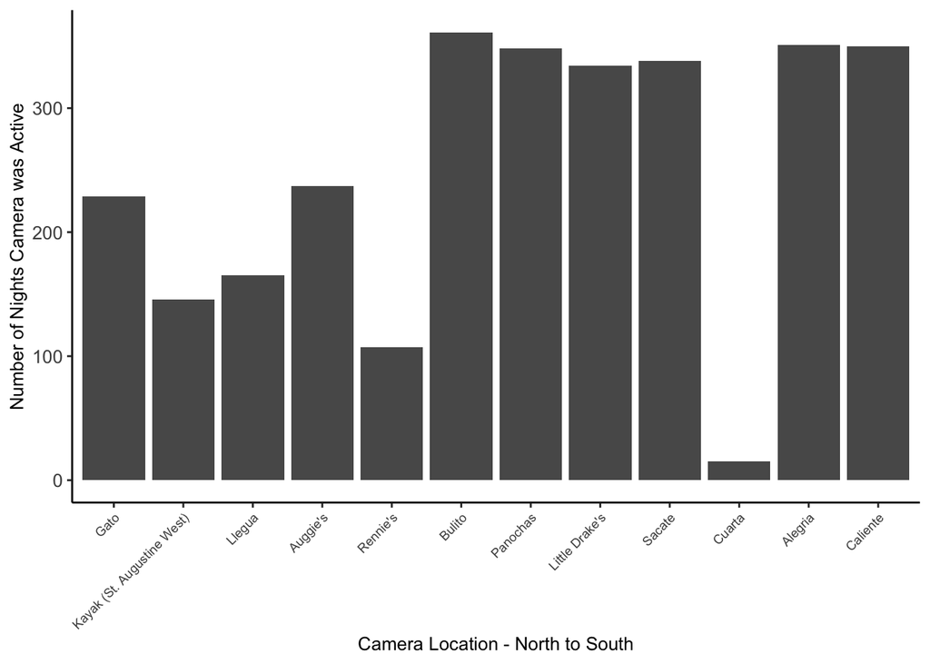

### Total images taken at each location (including animal images, human images, and blanks)

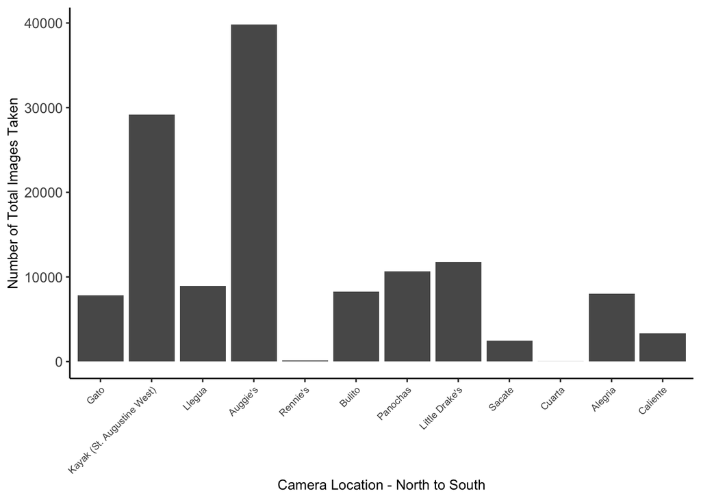

### Percent of images that contained animals at each location (this corrects for different numbers of images taken at different locations, better for comparing sites to each other)

[figure not shown]

### What wildlife species were seen across the whole ranch and how many times?

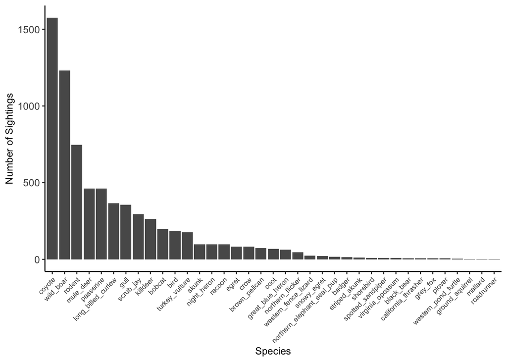

### How many times was each species seen at each location?

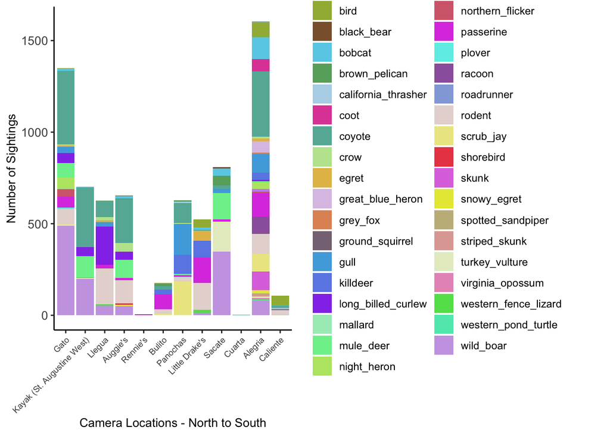

### How *frequently* was each species seen at each location, relatively?

#### These pie charts use relative frequency (percent of total wildlife sightings) to correct for differences in detection between cameras

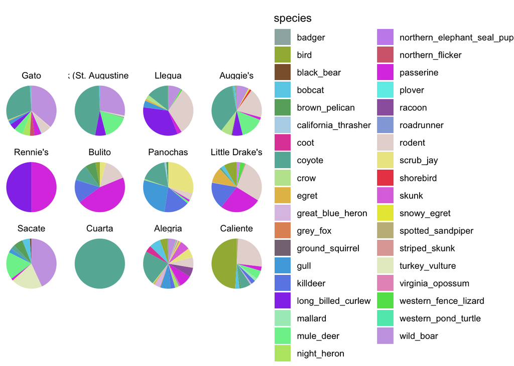

### How many times were humans and domestic animals seen at each location?

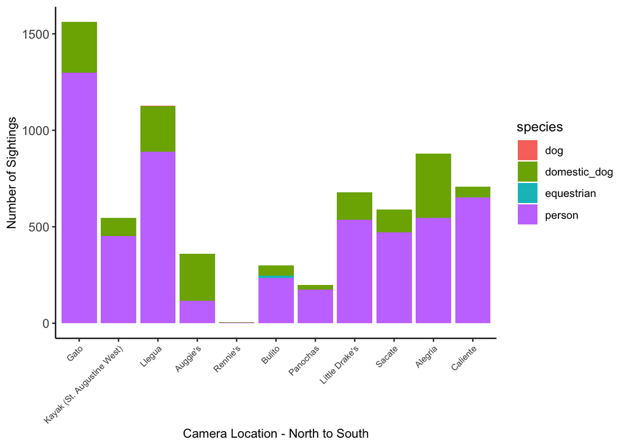

### Wildlife sightings per month, broken down by species

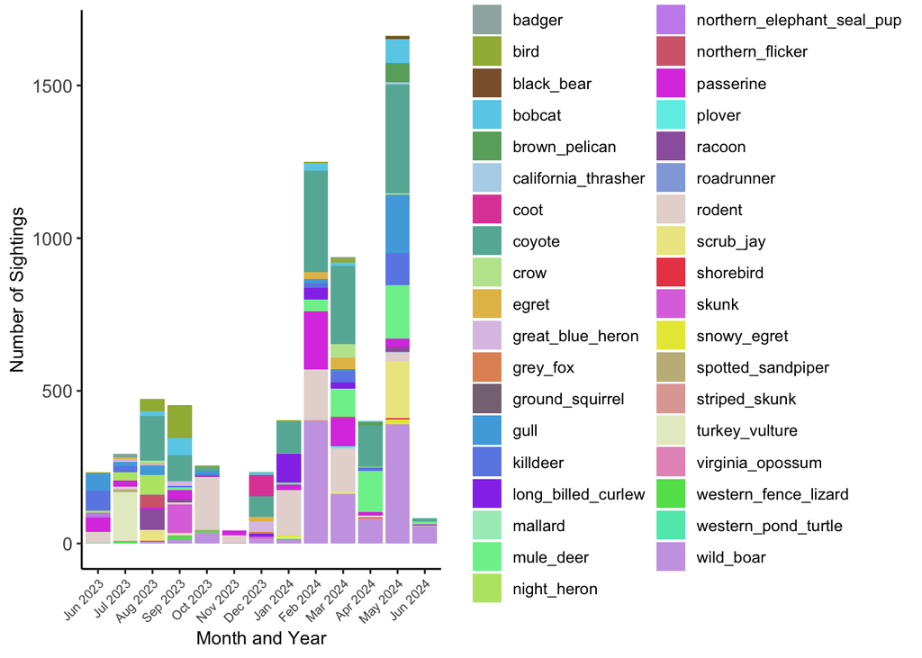

### Is there a relationship between people sightings and wildlife sightings?

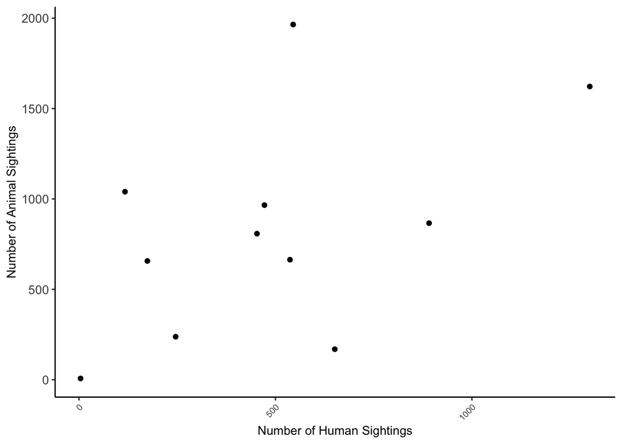

### Is there a relationship between people sightings and wildlife species richness (# species)?

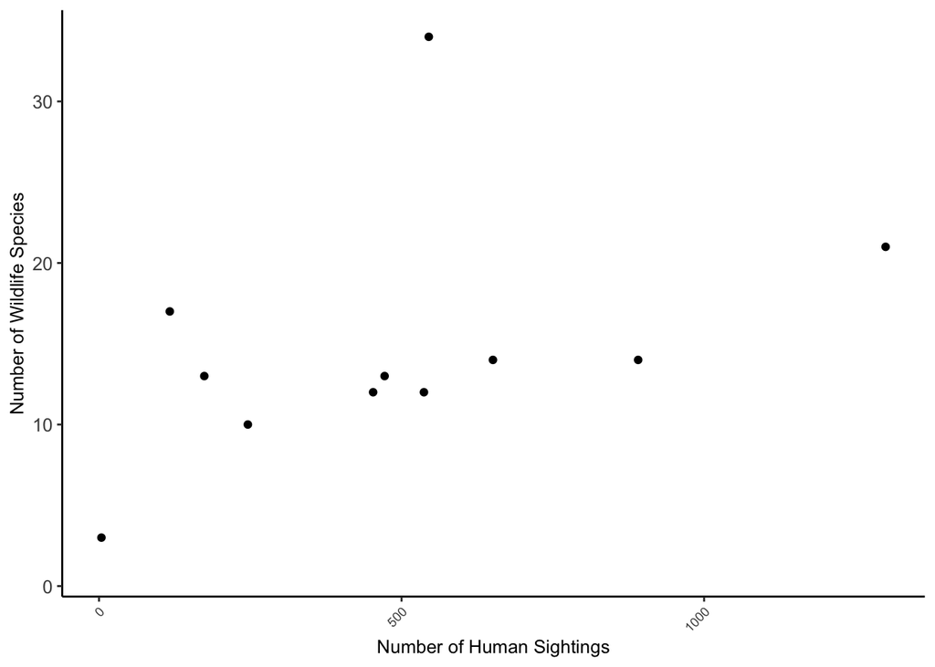

#### Seems like a slight positive correlation between wildlife sightings and human sightings, which is likely a result of camera performance, e.g. some cameras take more pictures and just capture more humans and more wildlife.